# Hearthstone Decks (on Hearthpwn)

## 0. Questions to address

1. Which are the most popular cards used in Ranked/ladder decks?
2. Are there any cards that are not used in Ranked decks?

### Approach and Considerations

- Group by expansion and class
- Only consider decks used in certain modes (Ranked, Tournament, Arena)
- Dataset contains decks built in beta (before game launch)

## 1.1 Setup

Any packages that are needed for data analysis

```r
library(dplyr)
library(ggplot2)
library(jsonlite)
library(readr)
library(stringr)
library(tidyr)
library(zoo)
```

## 1.2 Loading the data

```r
hsdecks <- read_csv("data.csv")
hscards <- fromJSON("refs.json")
```

## 2.1 Examining the hsdecks dataset

Size of the dataset and column names

```r
dim(hsdecks)
```

```
## [1] 346232     41
```

```r
names(hsdecks)
```

```
##  [1] "craft_cost"     "date"           "deck_archetype" "deck_class"
##  [5] "deck_format"    "deck_id"        "deck_set"       "deck_type"
##  [9] "rating"         "title"          "user"           "card_0"
## [13] "card_1"         "card_2"         "card_3"         "card_4"
## [17] "card_5"         "card_6"         "card_7"         "card_8"
## [21] "card_9"         "card_10"        "card_11"        "card_12"
## [25] "card_13"        "card_14"        "card_15"        "card_16"
## [29] "card_17"        "card_18"        "card_19"        "card_20"
## [33] "card_21"        "card_22"        "card_23"        "card_24"
## [37] "card_25"        "card_26"        "card_27"        "card_28"
## [41] "card_29"
```

Overview of columns and data types

```r
glimpse(hsdecks)
```

```
## Observations: 346,232
## Variables: 41
## $ craft_cost     <int> 9740, 9840, 2600, 15600, 7700, 5740, 1800, 1800...
## $ date           <date> 2016-02-19, 2016-02-19, 2016-02-19, 2016-02-19...
## $ deck_archetype <chr> "Unknown", "Unknown", "Unknown", "Unknown", "Un...
## $ deck_class     <chr> "Priest", "Warrior", "Mage", "Warrior", "Paladi...
## $ deck_format    <chr> "W", "W", "W", "W", "W", "W", "W", "W", "W", "W...
## $ deck_id        <int> 433004, 433003, 433002, 433001, 432997, 432995,...
## $ deck_set       <chr> "Explorers", "Explorers", "Explorers", "Explore...
## $ deck_type      <chr> "Tavern Brawl", "Ranked Deck", "Theorycraft", "...
## $ rating         <int> 1, 1, 1, 0, 1, 2, 1, 1, 1, 1, 1, 2, 1, 1, 1, 1,...
## $ title          <chr> "Reno Priest", "RoosterWarrior", "Annoying", "S...
## $ user           <chr> "FunKaliTy", "RooosterRooo", "Messalm", "KingSn...
## $ card_0         <int> 9, 75, 195, 75, 476, 75, 1007, 48, 272, 147, 11...
## $ card_1         <int> 237, 75, 195, 290, 476, 75, 90, 48, 613, 290, 3...
```

[output cut: 28 more lines]

Are there any rows containing missing data?

```r
sum(!complete.cases(hsdecks))
```

```
## [1] 8
```

Missing data only in column 10, which is the `title` column. They can be ignored.

```r
which(is.na(hsdecks), arr.ind = TRUE)
```

```
##         row col
## [1,]  16747  10
## [2,] 175608  10
## [3,] 216047  10
## [4,] 238021  10
## [5,] 278491  10
## [6,] 326192  10
## [7,] 329285  10
## [8,] 329286  10
```

## 2.2 Pre-processing: decks

Split the dataset into two: one contains the deck attributes, the other contains the cards used in each deck (composition)

```r
deck_attr <- select(hsdecks, craft_cost:user)

deck_comp <- select(hsdecks, deck_id, card_0:card_29)
```

Defining factor columns

```r
fct_cols <- c("deck_archetype", "deck_class", "deck_format", "deck_set", "deck_type")

deck_attr[fct_cols] <- lapply(deck_attr[fct_cols], factor)
```

Defining additional variables

```r
# distinct colors for each class
class_colors <- c(
    "Druid" = "#FF7D0A",
    "Hunter" = "#ABD473",
    "Mage" = "#40C7EB",
    "Paladin" = "#F58CBA",
    "Priest" = "#FFFFFF",
    "Rogue" = "#FFF569",
    "Shaman" = "#0070DE",
    "Warlock" = "#8787ED",
    "Warrior" = "#C79C6E",
    "Neutral" = "#777777"
)

# game launch date
launch_date = as.Date("2014-03-11")

# card sets/expansions up until Mar 2017
releases_filt <- c("Beta Patch 4944", "Naxx Launch", "GvG Launch", "Blackrock Launch",
  "TGT Launch", "Explorers", "Old Gods", "Karazhan", "Gadgetzan")
# abbreviated forms for plot annotations
releases_abbr <- c("Launch", "Naxx", "GvG", "Blackrock", "TGT",
                   "Explorers", "Old Gods", "Karazhan", "Gadgetzan")

# release dates of expansions as a dataframe
releases <- deck_attr %>%
    filter(deck_set %in% releases_filt) %>%
    group_by(deck_set) %>%
    summarise(release = min(date)) %>%
    ungroup() %>%
    mutate(deck_set = recode(deck_set, "Beta Patch 4944" = "Live")) %>%
    arrange(release)

# release dates of expansions as a named vector
release_dates <- releases[["release"]]
names(release_dates) <- releases[["deck_set"]]
```

Exclude beta/pre-launch decks from this dataset

```r
deck_attr <- filter(deck_attr, date >= launch_date)
```

For `deck_format`: all decks prior to the Old Gods expansion can be considered Standard. Two options for pre-processing:

- Change all decks from 2014-03-11 to 2016-04-25 to “S” format
- Ignore all “W” decks from 2016-04-26 onwards if looking at standard decks

(First option leads to easier analyses later on since wild decks can be quickly filtered out)

```r
deck_attr$deck_format[deck_attr$date < release_dates["Old Gods"]] <- "S"
```

Overview of pre-processed `deck_attr` dataset

```r
glimpse(deck_attr)
```

```
## Observations: 324,104
## Variables: 11
## $ craft_cost     <int> 9740, 9840, 2600, 15600, 7700, 5740, 1800, 1800...
## $ date           <date> 2016-02-19, 2016-02-19, 2016-02-19, 2016-02-19...
## $ deck_archetype <fct> Unknown, Unknown, Unknown, Unknown, Unknown, Un...
## $ deck_class     <fct> Priest, Warrior, Mage, Warrior, Paladin, Warrio...
## $ deck_format    <fct> S, S, S, S, S, S, S, S, S, S, S, S, S, S, S, S,...
## $ deck_id        <int> 433004, 433003, 433002, 433001, 432997, 432995,...
## $ deck_set       <fct> Explorers, Explorers, Explorers, Explorers, Exp...
## $ deck_type      <fct> Tavern Brawl, Ranked Deck, Theorycraft, None, R...
## $ rating         <int> 1, 1, 1, 0, 1, 2, 1, 1, 1, 1, 1, 2, 1, 1, 1, 1,...
## $ title          <chr> "Reno Priest", "RoosterWarrior", "Annoying", "S...
## $ user           <chr> "FunKaliTy", "RooosterRooo", "Messalm", "KingSn...
```

## 2.3 Data Exploration: deck_attr

Quick summary of deck attributes (excluding card columns)

```r
summary(deck_attr)
```

```
##    craft_cost         date                    deck_archetype
##  Min.   :    0   Min.   :2014-03-11   Unknown        :220501
##  1st Qu.: 2840   1st Qu.:2015-05-26   Midrange Shaman:  5472
##  Median : 5120   Median :2016-02-09   Control Priest :  5135
##  Mean   : 5745   Mean   :2015-12-21   Control Warrior:  4939
##  3rd Qu.: 7840   3rd Qu.:2016-08-09   Tempo Mage     :  4545
##  Max.   :48000   Max.   :2017-03-19   Midrange Hunter:  4371
##                                       (Other)        : 79141
##    deck_class    deck_format    deck_id                   deck_set
##  Mage   :42230   S:307743    Min.   : 36923   Explorers       : 57307
##  Priest :41756   W: 16361    1st Qu.:253573   Old Gods        : 49895
##  Paladin:39368               Median :428597   Blackrock Launch: 38900
##  Warlock:35598               Mean   :419989   Gadgetzan       : 31329
##  Druid  :35488               3rd Qu.:603508   Naxx Launch     : 22283
##  Shaman :33969               Max.   :749548   Yogg Nerf       : 22175
##  (Other):95695                                (Other)         :102215
##          deck_type          rating            title
##  Arena        :  8178   Min.   :   0.000   Length:324104
##  None         : 75120   1st Qu.:   1.000   Class :character
##  PvE Adventure:  9059   Median :   1.000   Mode  :character
##  Ranked Deck  :202104   Mean   :   2.777
##  Tavern Brawl :  6360   3rd Qu.:   1.000
##  Theorycraft  : 19686   Max.   :4016.000
##  Tournament   :  3597
##      user
##  Length:324104
##  Class :character
##  Mode  :character
##
##
##
##
```

Visualizing the number of decks submitted for Ranked/Ladder games on a monthly basis

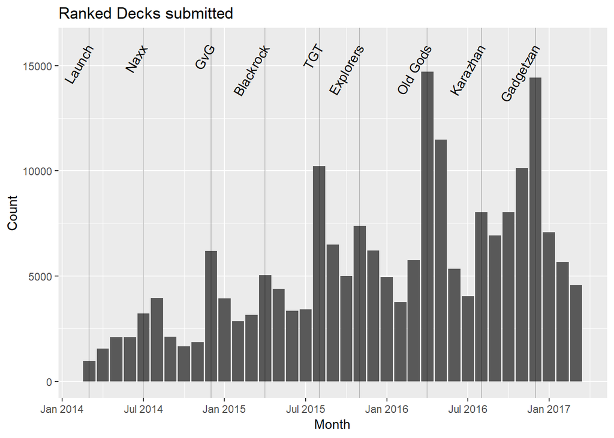

```r
deck_attr %>%
    filter(deck_type == "Ranked Deck") %>%
    ggplot(aes(x = as.yearmon(date))) +
    geom_bar() +
    scale_x_yearmon() +
    geom_vline(xintercept = as.yearmon(release_dates), alpha = 0.2) +
    annotate("text", label = releases_abbr,
             x = as.yearmon(release_dates), y = 16000,
             hjust = 1, angle = 60) +
    labs(title = "Ranked Decks submitted",
         x = "Month",
         y = "Count")
```

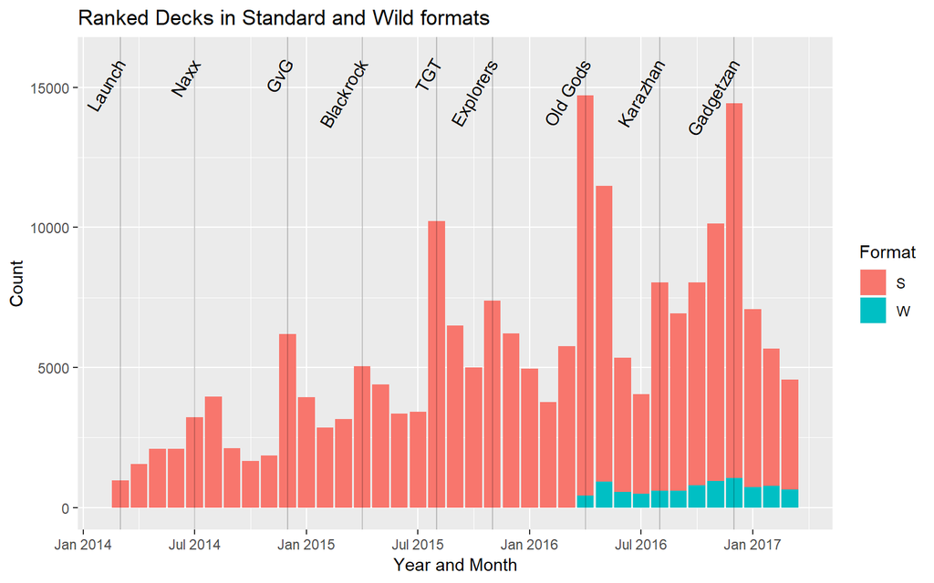

```r
deck_attr %>%
    filter(deck_type == "Ranked Deck") %>%
    ggplot(aes(x = as.yearmon(date), fill = deck_format)) +
    geom_bar() +
    scale_x_yearmon() +
    geom_vline(xintercept = as.yearmon(release_dates), alpha = 0.2) +
    annotate("text", label = releases_abbr,
             x = as.yearmon(release_dates), y = 16000,
             hjust = 1, angle = 60) +
    labs(title = "Ranked Decks in Standard and Wild formats",
         x = "Year and Month",
         y = "Count",
         fill = "Format")
```

Class representation in Ranked Decks over time

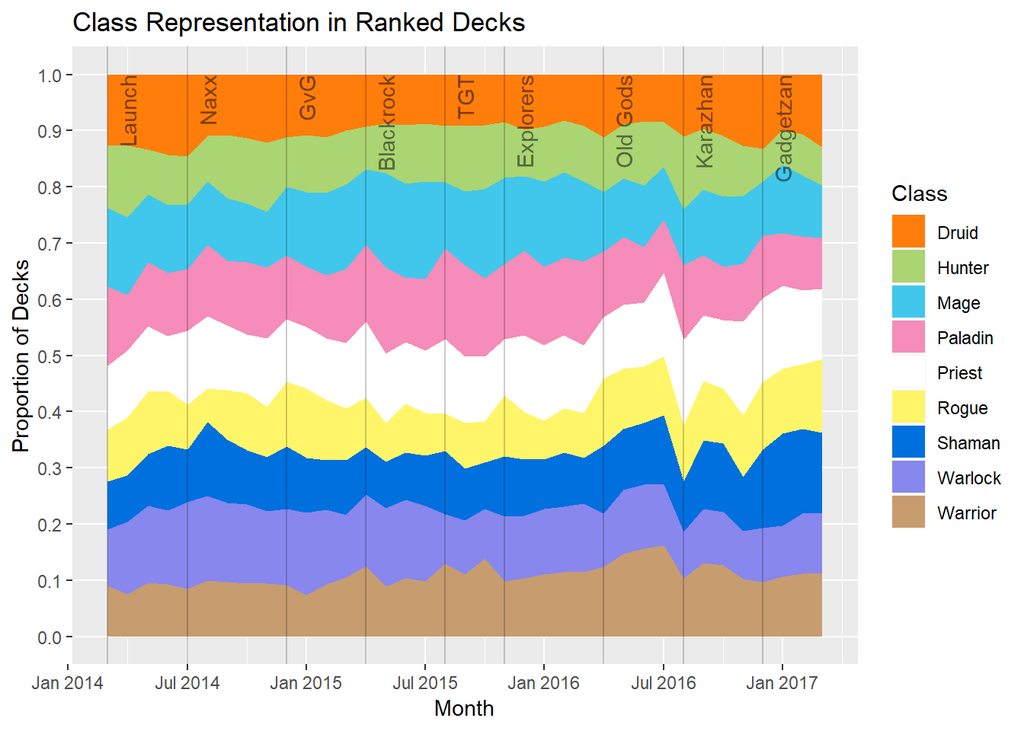

```r
deck_attr %>%
    filter(deck_type == "Ranked Deck",
           deck_format == "S") %>%
    ggplot(aes(x = as.yearmon(date), fill = deck_class)) +
    geom_area(stat = "count", position = "fill") +
    scale_x_yearmon() +
    scale_y_continuous(breaks = seq(0, 1, 0.1), minor_breaks = NULL) +
    scale_fill_manual(values = class_colors) +
    geom_vline(xintercept = as.yearmon(release_dates), alpha = 0.2) +
    annotate("text", label = releases_abbr,
             x = as.yearmon(release_dates) + 0.09, y = 1,
             hjust = 1, angle = 90, alpha = 0.5) +
    labs(title = "Class Representation in Ranked Decks",
         x = "Month", y = "Proportion of Decks",
         fill = "Class")
```

## 3.1 Examining the hscards dataset

```r
dim(hscards)
```

```
## [1] 3117   32
```

```r
names(hscards)
```

```
##  [1] "artist"             "attack"             "cardClass"
##  [4] "collectible"        "cost"               "dbfId"
##  [7] "flavor"             "health"             "id"
## [10] "name"               "playerClass"        "rarity"
## [13] "referencedTags"     "set"                "text"
## [16] "type"               "elite"              "mechanics"
## [19] "howToEarnGolden"    "race"               "playRequirements"
## [22] "howToEarn"          "targetingArrowText" "durability"
## [25] "entourage"          "faction"            "overload"
## [28] "spellDamage"        "hideStats"          "classes"
## [31] "multiClassGroup"    "collectionText"
```

Overview of columns and data types. There are two ID columns, but only `dbfId` lets us to look up the cards in the `deck_comp` dataset.

Also note the following list-like columns:

- `referencedTags`
- `mechanics`
- `playRequirements`
- `entourage`
- `classes`

```r
glimpse(hscards)
```

```
## Observations: 3,117
## Variables: 32
## $ artist             <chr> "Jakub Kasper", NA, NA, "Mauricio Herrera",...
## $ attack             <int> 4, 4, NA, 3, 2, NA, NA, 4, NA, NA, 2, 1, 4,...
## $ cardClass          <chr> "NEUTRAL", "NEUTRAL", "NEUTRAL", "WARRIOR",...
## $ collectible        <lgl> TRUE, NA, NA, TRUE, TRUE, NA, NA, NA, NA, T...
## $ cost               <int> 4, 6, NA, 3, 4, 2, NA, 3, 0, 3, 3, 0, 4, 3,...
## $ dbfId              <int> 2518, 1769, 10081, 40569, 1370, 19292, 2751...
## $ flavor             <chr> "The crowd ALWAYS yells lethal.", NA, NA, "...
## $ health             <int> 4, 7, NA, 3, 7, NA, NA, 2, NA, NA, 2, 1, 7,...
## $ id                 <chr> "AT_121", "CRED_09", "TB_007e", "CFM_755", ...
## $ name               <chr> "Crowd Favorite", "Ben Thompson", "Deviate ...
## $ playerClass        <chr> "NEUTRAL", "NEUTRAL", "NEUTRAL", "WARRIOR",...
## $ rarity             <chr> "EPIC", "LEGENDARY", NA, "RARE", "FREE", NA...
## $ referencedTags     <list> ["BATTLECRY", NULL, NULL, NULL, NULL, NULL...
```

[output cut: 19 more lines]

Amount of missing data in every column (in the form of `NA`, not `NULL`)

The list-like columns will usually return 0.

`playRequirements` is a nested data frame, so the following calculation retrieves the number of NA values in the entire data frame, rather than the number of rows containing missing data (use `complete.cases()` if attempting to answer the latter query.)

```r
sapply(hscards, function(x) sum(is.na(x)))
```

```
##             artist             attack          cardClass
##               1590               1686                  3
##        collectible               cost              dbfId
##               1911                697                  1
##             flavor             health                 id
##               1924               1578                  0
##               name        playerClass             rarity
##                  1                  3               1519
##     referencedTags                set               text
##                  0                  1                452
##               type              elite          mechanics
##                  1               2764                  0
##    howToEarnGolden               race   playRequirements
##               2827               2682             101994
##          howToEarn targetingArrowText         durability
##               2872               3061               3046
##          entourage            faction           overload
##                  0               3045               3092
##        spellDamage          hideStats            classes
##               3100               3097                  0
##    multiClassGroup     collectionText
##               3108               3105
```

## 3.2 Pre-processing: cards

Consider extracting a simplified/thinner dataframe that creates less confusion when joined with the `deck_attr` dataset. We only include collectible cards (i.e. exclude generated cards/tokens)

```r
simple_cards <- hscards %>%
    # drop the nested df prior to filtering to avoid errors
    select(-playRequirements) %>%
    filter(collectible == TRUE) %>%
    select(dbfId, name, cost, cardClass, rarity, type, set, collectible)
```

The `set` column indicates which card set each cards belong to. We’ll recode the relevant expansions for easier recognition:

```r
unique(simple_cards$set)
```

```
##  [1] "TGT"        "GANGS"      "CORE"       "UNGORO"     "EXPERT1"
##  [6] "HOF"        "OG"         "BRM"        "GVG"        "KARA"
## [11] "LOE"        "NAXX"       "HERO_SKINS"
```

(Note: the other sets are “HERO_SKINS” = alternate heroes for classes)

```r
cardset_lst <- list(
    "CORE" = "Basic",
    "EXPERT1" = "Classic",
    "NAXX" = "Curse of Naxxramas",
    "GVG" = "Goblins vs Gnomes",
    "BRM" = "Blackrock Mountain",
    "TGT" = "The Grand Tournament",
    "LOE" = "League of Explorers",
    "OG" = "Whispers of the Old Gods",
    "KARA" = "One Night in Karazhan",
    "GANGS" = "Mean Streets of Gadgetzan",
    "UNGORO" = "Journey to Un'Goro",
    "HOF" = "Hall of Fame"
)

simple_cards$card_set <- recode(simple_cards$set, !!!cardset_lst,
                                .default = "Other")

# drop the set column to avoid later confusion (it remains in the  original dataset)
simple_cards$set <- NULL
```

Resolve columns that are entirely in uppercase:

```r
titlecase_cols <- c("cardClass", "rarity", "type")
simple_cards[titlecase_cols] <- lapply(simple_cards[titlecase_cols], str_to_title)
```

Define factor columns

```r
fct_cols2 <- c("cardClass", "rarity", "type", "card_set")

simple_cards[fct_cols2] <- lapply(simple_cards[fct_cols2], factor)
```

### Mislabelled cards

As the `hsdecks` data is generated by human input, and multiple cards with the same name can exist in the `hscards` data, it is recommended to check for mislabelled cards. Specifically, we are looking for the version of each card that is collectible (since all cards used in Ranked decks must be collectible).

```r
# ids of all cards used
cards_used <- deck_comp %>%
    select(card_0:card_29) %>%
    unlist() %>%  # flatten into a vector
    unique() %>%
    sort()

# how many cards are not found in the (collectible) simple_cards df?
sum(!(cards_used %in% simple_cards$dbfId))
```

```
## [1] 55
```

Locating the missing cards

```r
missing_cards <- cards_used[!(cards_used %in% simple_cards$dbfId)]

mcards_df <- hscards %>%
    select(-playRequirements) %>%
    filter(dbfId %in% missing_cards) %>%
    select(dbfId, name, cardClass, type, collectible)

glimpse(mcards_df)
```

```
## Observations: 55
## Variables: 5
## $ dbfId       <int> 1746, 38710, 100, 40341, 988, 1145, 329, 40402, 16...
## $ name        <chr> "The Coin", "Unstable Portal", "Huffer", "Cleave",...
## $ cardClass   <chr> "NEUTRAL", "NEUTRAL", "HUNTER", "NEUTRAL", "NEUTRA...
## $ type        <chr> "SPELL", "HERO_POWER", "MINION", "SPELL", "SPELL",...
## $ collectible <lgl> NA, NA, NA, NA, NA, NA, NA, NA, NA, NA, NA, NA, NA...
```

Joining to `simple_cards` by name instead of id produces a list of cards with the incorrect card Ids on the left, followed by the name and correct Ids:

```r
mislabelled <- mcards_df %>%
    select(dbfId, name) %>%
    # also drops uncollectible mislabelled cards (which are not in simple_cards)
    inner_join(simple_cards, by = "name") %>%
    arrange(name)

head(mislabelled)
```

```
##   dbfId.x               name dbfId.y cost cardClass rarity   type
## 1   40341             Cleave     940    2   Warrior   Free  Spell
## 2    2177       Dark Wispers    2009    6     Druid   Epic  Spell
## 3   42146     Doppelgangster   40953    5   Neutral   Rare Minion
## 4   38319  Druid of the Claw     692    5     Druid Common Minion
## 5    2230  Druid of the Fang    2048    5     Druid Common Minion
## 6    2310 Druid of the Flame    2292    3     Druid Common Minion
##   collectible                  card_set
## 1        TRUE                     Basic
## 2        TRUE         Goblins vs Gnomes
## 3        TRUE Mean Streets of Gadgetzan
## 4        TRUE                   Classic
## 5        TRUE         Goblins vs Gnomes
## 6        TRUE        Blackrock Mountain
```

Create a named list for recoding

```r
# list values are correct ids
mislab_lst <- as.list(mislabelled$dbfId.y)
# list names are mislabelled ids
names(mislab_lst) <- mislabelled$dbfId.x
```

## 3.3 Data Exploration: simple_cards

Quick summary of simplified card attributes

```r
summary(simple_cards)
```

```
##      dbfId           name                cost         cardClass
##  Min.   :    7   Length:1206        Min.   : 0.00   Neutral:477
##  1st Qu.: 1000   Class :character   1st Qu.: 2.00   Hunter : 82
##  Median : 2520   Mode  :character   Median : 3.00   Mage   : 82
##  Mean   :16017                      Mean   : 3.76   Paladin: 81
##  3rd Qu.:39408                      3rd Qu.: 5.00   Priest : 81
##  Max.   :42046                      Max.   :25.00   Rogue  : 81
##                                     NA's   :17      (Other):322
##        rarity        type     collectible
##  Common   :416   Hero  : 17   Mode:logical
##  Epic     :185   Minion:823   TRUE:1206
##  Free     :142   Spell :332
##  Legendary:161   Weapon: 34
##  Rare     :302
##
##
##                       card_set
##  Classic                  :239
##  Basic                    :142
##  Journey to Un'Goro       :135
##  Whispers of the Old Gods :134
##  Mean Streets of Gadgetzan:132
##  The Grand Tournament     :132
##  (Other)                  :292
```

Examining the mana cost distribution for class and neutral cards:

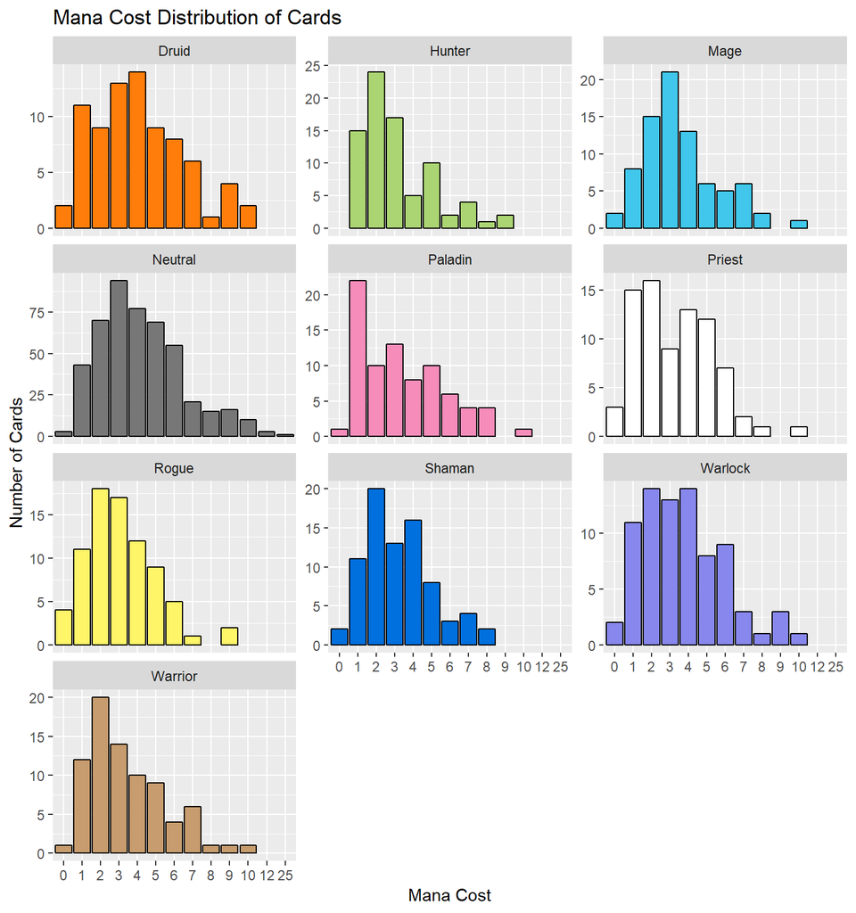

```r
simple_cards %>%
    filter(!is.na(cost)) %>% # exclude cards without a cost
    ggplot(aes(x = factor(cost), fill = cardClass)) +
    geom_bar(color = "black") +
    facet_wrap(~cardClass, ncol = 3, scales = "free_y") +
    scale_fill_manual(values = class_colors, guide = FALSE) +
    labs(title = "Mana Cost Distribution of Cards",
         x = "Mana Cost", y = "Number of Cards")
```

## 4 Popular Cards

We’ll start by asking the general question:

> Which are the most popular cards used in all Ranked decks, across the different expansions/card sets?

There can be up to 2 copies of a free/common/rare/epic card in each deck, and up to 1 copy of a legendary card in each deck.

We’ll simplify this question by counting the number of decks which include at least 1 copy of the card in question.

First, we pivot the `deck_comp` data to find out which cards (and number of copies) each deck uses:

```r
ranked_qtys <- deck_attr %>%
    # only look at Ranked decks
    filter(deck_type == "Ranked Deck") %>%
    select(deck_id) %>%
    inner_join(deck_comp, by = "deck_id") %>%
    # pivot the card IDs (wide to long)
    gather(card, card_id, card_0:card_29) %>%
    group_by(deck_id, card_id) %>%
    summarise(quantity = n()) %>%
    ungroup()
ranked_qtys
```

```
## # A tibble: 3,984,401 x 3
##    deck_id card_id quantity
##      <int>   <int>    <int>
##  1   36923      69        2
##  2   36923      70        1
##  3   36923     250        1
##  4   36923     281        2
##  5   36923     291        2
##  6   36923     351        1
##  7   36923     383        2
##  8   36923     420        1
##  9   36923     462        2
## 10   36923     642        1
## # ... with 3,984,391 more rows
```

Data validation:

```r
# only 1 and 2 should be present
unique(ranked_qtys$quantity)
```

```
## [1] 2 1
```

```r
# there should be 0 NA values
sum(is.na(ranked_qtys$quantity))
```

```
## [1] 0
```

```r
# any missing cards?
sum(!(unique(ranked_qtys$card_id) %in% simple_cards$dbfId))
```

```
## [1] 15
```

```r
# what are their ids?
unique(ranked_qtys$card_id)[!(unique(ranked_qtys$card_id) %in% simple_cards$dbfId)]
```

```
##  [1]   137   468  1161 38319 40341 41609 38113 38653 38710  2177 40402
## [12]  2310  2230 41409 42146
```

Use the list earlier to relabel missing cards:

```r
ranked_qtys <- ranked_qtys %>%
    mutate(card_id = recode(card_id, !!!mislab_lst))
```

```r
pop_cards_all <- ranked_qtys %>%
    group_by(card_id) %>%
    summarise(n_decks = n(),
              pct_all = n_decks * 100 / nrow(deck_attr)) %>%
    # look up each card from the simple_cards data
    left_join(simple_cards, by = c("card_id" = "dbfId")) %>%
    ungroup()

pop_cards_all %>%
    select(name, cardClass, type, rarity, card_set, n_decks, pct_all) %>%
    arrange(desc(n_decks))
```

```
## # A tibble: 1,054 x 7
##    name            cardClass type   rarity  card_set       n_decks pct_all
##    <chr>           <fct>     <fct>  <fct>   <fct>            <int>   <dbl>
##  1 Azure Drake     Neutral   Minion Rare    Hall of Fame     63817   19.7
##  2 Sylvanas Windr~ Neutral   Minion Legend~ Hall of Fame     49049   15.1
##  3 Dr. Boom        Neutral   Minion Legend~ Goblins vs Gn~   39551   12.2
##  4 Emperor Thauri~ Neutral   Minion Legend~ Blackrock Mou~   39159   12.1
##  5 Sludge Belcher  Neutral   Minion Rare    Curse of Naxx~   37975   11.7
##  6 Defender of Ar~ Neutral   Minion Rare    Classic          32083    9.90
##  7 Piloted Shredd~ Neutral   Minion Common  Goblins vs Gn~   31176    9.62
##  8 Ragnaros the F~ Neutral   Minion Legend~ Hall of Fame     30668    9.46
##  9 Acolyte of Pain Neutral   Minion Common  Classic          29453    9.09
## 10 Bloodmage Thal~ Neutral   Minion Legend~ Classic          29202    9.01
## # ... with 1,044 more rows
```

NB: Cards that are in the Hall of Fame used to be in the Classic set but were subsequently removed from Standard format to improve card diversity across decks and the metagame.

The most popular cards are clearly Neutral class, as they can be used by all 9 classes; class-specific cards would be less popular.

Such a question is also biased towards cards from the Basic and Classic sets as they are always part of the Standard format and have been introduced when the game was launched.

[figure not shown]

[figure not shown]

[figure not shown]

[figure not shown]

[figure not shown]

### 4.2 Cards by Class

> For each class, which are the most popular Class-specific cards used in all Ranked decks?

```r
pop_cards_class <- pop_cards_all %>%
    filter(!is.na(cardClass), cardClass != "Neutral") %>%
    group_by(cardClass) %>%
    mutate(class_rank = min_rank(desc(n_decks))) %>%
    select(cardClass, class_rank, card_id, name, type, n_decks)

pop_cards_class %>%
    select(-card_id) %>%
    top_n(3, n_decks) %>%
    arrange(cardClass, class_rank) %>%
    print(n = nrow(.))
```

```
## # A tibble: 27 x 5
## # Groups:   cardClass [9]
##    cardClass class_rank name                type   n_decks
##    <fct>          <int> <chr>               <fct>    <int>
##  1 Druid              1 Swipe               Spell    19220
##  2 Druid              2 Innervate           Spell    18767
##  3 Druid              3 Wrath               Spell    17518
##  4 Hunter             1 Animal Companion    Spell    16428
##  5 Hunter             2 Kill Command        Spell    15225
##  6 Hunter             3 Eaglehorn Bow       Weapon   14511
##  7 Mage               1 Frostbolt           Spell    23418
##  8 Mage               2 Fireball            Spell    21858
##  9 Mage               3 Arcane Intellect    Spell    19130
## 10 Paladin            1 Truesilver Champion Weapon   21387
## 11 Paladin            2 Consecration        Spell    21105
```

[output cut: 16 more lines]

[figure not shown]

[figure not shown]

[figure not shown]

[figure not shown]

[figure not shown]

[figure not shown]

[figure not shown]

[figure not shown]

[figure not shown]

### 4.3 Cards by Time Period

> Which are the most popular cards used in Standard Ranked decks every year?

Recall that the `hsdecks` data spans about 3 years, from March 2014 to March 2017. Years in the game based on a time period that:

- Starts with the release of the first card set of each year, which usually falls around April.
- Ends with the release of the first card set the next year (non-inclusive).

```r
release_dates
```

```
##             Live      Naxx Launch       GvG Launch Blackrock Launch
##     "2014-03-10"     "2014-07-22"     "2014-12-08"     "2015-04-02"
##       TGT Launch        Explorers         Old Gods         Karazhan
##     "2015-08-24"     "2015-11-12"     "2016-04-26"     "2016-08-09"
##        Gadgetzan
##     "2016-12-01"
```

So based on the release dates above, the years would be:

- 2014-03-11 to 2015-04-01 (Live, Naxxramas, Goblin vs Gnomes)
- 2015-04-02 to 2016-04-25 (Blackrock, Grand Tournament, League of Explorers)
- 2016-04-26 to 2017-03-19 (Old Gods, Karazhan, Gadgetzan); aka Year of the Kraken
  - Splits into Standard and Wild formats

```r
deck_attr <- deck_attr %>%
    mutate(hsyear = case_when(
        date <= as.Date("2015-04-01") ~ "2014",
        date >= as.Date("2015-04-02") &
            date <= as.Date("2016-04-25") ~ "2015",
        date >= as.Date("2016-04-25") ~ "2016"
    ) %>%
        factor())
```

```r
ranked_byyear <- deck_attr %>%
    filter(deck_type == "Ranked Deck",
           deck_format == "S") %>%
    select(deck_id, hsyear) %>%
    inner_join(deck_comp, by = "deck_id") %>%
    gather(card, card_id, card_0:card_29) %>%
    mutate(card_id = recode(card_id, !!!mislab_lst)) %>%
    distinct(hsyear, deck_id, card_id)
ranked_byyear
```

```
## # A tibble: 3,806,924 x 3
##    deck_id hsyear card_id
##      <int> <fct>    <int>
##  1  433003 2015        75
##  2  432997 2015       476
##  3  432995 2015        75
##  4  432992 2015       272
##  5  432990 2015       113
##  6  432989 2015        77
##  7  432987 2015       251
##  8  432984 2015       242
##  9  432982 2015       290
## 10  432978 2015       180
## # ... with 3,806,914 more rows
```

Popular cards by year:

```r
pop_byyear <- ranked_byyear %>%
    group_by(hsyear, card_id) %>%
    summarise(n_decks = n()) %>%
    # look up each card from the simple_cards data
    left_join(simple_cards, by = c("card_id" = "dbfId")) %>%
    select(hsyear, name, card_id, cardClass, type, rarity, card_set, n_decks)

pop_byyear %>%
    select(hsyear, name, cardClass, type, rarity, card_set, n_decks) %>%
    top_n(5, n_decks) %>%
    arrange(hsyear, desc(n_decks))
```

```
## # A tibble: 15 x 7
## # Groups:   hsyear [3]
##    hsyear name            cardClass type   rarity  card_set        n_decks
##    <fct>  <chr>           <fct>     <fct>  <fct>   <fct>             <int>
##  1 2014   Sludge Belcher  Neutral   Minion Rare    Curse of Naxxr~   10490
##  2 2014   Defender of Ar~ Neutral   Minion Rare    Classic            8832
##  3 2014   Harvest Golem   Neutral   Minion Common  Classic            8814
##  4 2014   Loatheb         Neutral   Minion Legend~ Curse of Naxxr~    8628
##  5 2014   Azure Drake     Neutral   Minion Rare    Hall of Fame       8404
##  6 2015   Dr. Boom        Neutral   Minion Legend~ Goblins vs Gno~   31770
##  7 2015   Sludge Belcher  Neutral   Minion Rare    Curse of Naxxr~   24227
##  8 2015   Piloted Shredd~ Neutral   Minion Common  Goblins vs Gno~   23333
##  9 2015   Emperor Thauri~ Neutral   Minion Legend~ Blackrock Moun~   20628
## 10 2015   Azure Drake     Neutral   Minion Rare    Hall of Fame      19844
## 11 2016   Azure Drake     Neutral   Minion Rare    Hall of Fame      34079
## 12 2016   Sylvanas Windr~ Neutral   Minion Legend~ Hall of Fame      21198
## 13 2016   Brann Bronzebe~ Neutral   Minion Legend~ League of Expl~   19699
## 14 2016   Bloodmage Thal~ Neutral   Minion Legend~ Classic           16779
## 15 2016   Emperor Thauri~ Neutral   Minion Legend~ Blackrock Moun~   16403
```

[figure not shown]

[figure not shown]

[figure not shown]

[figure not shown]

[figure not shown]

[figure not shown]

[figure not shown]

[figure not shown]

### 4.4 Cards by Month/Season

Ranked Seasons lasts for a month, so popularity of cards may shift with the ranked metagame when a new season starts:

```r
deck_attr <- deck_attr %>%
    mutate(hsmonth = as.yearmon(date))
str(deck_attr$hsmonth)
```

```
##  'yearmon' num [1:324104] Feb 2016 Feb 2016 Feb 2016 Feb 2016 ...
```

```r
ranked_bymonth <- deck_attr %>%
    filter(deck_type == "Ranked Deck",
           deck_format == "S") %>%
    select(hsmonth, deck_id, deck_class) %>%
    inner_join(deck_comp, by = "deck_id") %>%
    gather(card, card_id, card_0:card_29) %>%
    mutate(card_id = recode(card_id, !!!mislab_lst)) %>%
    distinct(hsmonth, deck_id, deck_class, card_id)
ranked_bymonth
```

```
## # A tibble: 3,806,924 x 4
##    hsmonth       deck_id deck_class card_id
##    <S3: yearmon>   <int> <fct>        <int>
##  1 Feb 2016       433003 Warrior         75
##  2 Feb 2016       432997 Paladin        476
##  3 Feb 2016       432995 Warrior         75
##  4 Feb 2016       432992 Priest         272
##  5 Feb 2016       432990 Mage           113
##  6 Feb 2016       432989 Mage            77
##  7 Feb 2016       432987 Rogue          251
##  8 Feb 2016       432984 Paladin        242
##  9 Feb 2016       432982 Warrior        290
## 10 Feb 2016       432978 Rogue          180
## # ... with 3,806,914 more rows
```

```r
sum(!(unique(ranked_bymonth$card_id) %in% simple_cards$dbfId))
```

```
## [1] 0
```

Popular cards by month

```r
pop_bymonth <- ranked_bymonth %>%
    group_by(hsmonth, deck_class, card_id) %>%
    summarise(n_decks = n()) %>%
    # look up each card from the simple_cards data
    left_join(simple_cards, by = c("card_id" = "dbfId")) %>%
    ungroup() %>%
    select(hsmonth, deck_class, name, card_id, cardClass, type, rarity, card_set, n_decks)
pop_bymonth
```

```
## # A tibble: 83,496 x 9
##    hsmonth deck_class name  card_id cardClass type  rari~ card_set n_decks
##    <S3: y> <fct>      <chr>   <int> <fct>     <fct> <fct> <fct>      <int>
##  1 Mar 20~ Druid      Cena~      36 Druid     Mini~ Lege~ Classic       28
##  2 Mar 20~ Druid      Pint~      37 Neutral   Mini~ Rare  Classic        1
##  3 Mar 20~ Druid      Fros~      41 Neutral   Mini~ Free  Basic          2
##  4 Mar 20~ Druid      Taur~      45 Neutral   Mini~ Comm~ Classic        2
##  5 Mar 20~ Druid      Swipe      64 Druid     Spell Free  Basic        118
##  6 Mar 20~ Druid      Stra~      68 Neutral   Mini~ Comm~ Classic        1
##  7 Mar 20~ Druid      Silv~      69 Neutral   Mini~ Comm~ Classic        3
##  8 Mar 20~ Druid      Star~      86 Druid     Spell Rare  Classic       58
##  9 Mar 20~ Druid      Chil~      90 Neutral   Mini~ Free  Basic         67
## 10 Mar 20~ Druid      Nour~      95 Druid     Spell Rare  Classic       23
## # ... with 83,486 more rows
```

```r
pop_bymonth %>%
    select(hsmonth, name, cardClass, type, card_set, n_decks) %>%
    group_by(hsmonth) %>%
    top_n(3, n_decks) %>%
    arrange(hsmonth, desc(n_decks))
```

```
## # A tibble: 112 x 6
## # Groups:   hsmonth [37]
##    hsmonth       name         cardClass type  card_set n_decks
##    <S3: yearmon> <chr>        <fct>     <fct> <fct>      <int>
##  1 Mar 2014      Frostbolt    Mage      Spell Basic        130
##  2 Mar 2014      Fireball     Mage      Spell Basic        129
##  3 Mar 2014      Consecration Paladin   Spell Basic        124
##  4 Apr 2014      Frostbolt    Mage      Spell Basic        200
##  5 Apr 2014      Fireball     Mage      Spell Basic        197
##  6 Apr 2014      Swipe        Druid     Spell Basic        187
##  7 May 2014      Swipe        Druid     Spell Basic        262
##  8 May 2014      Innervate    Druid     Spell Basic        260
##  9 May 2014      Wrath        Druid     Spell Classic      255
## 10 Jun 2014      Swipe        Druid     Spell Basic        290
## # ... with 102 more rows
```

```r
pop_bymonth %>%
    select(hsmonth, deck_class, name, cardClass, type, rarity, n_decks) %>%
    group_by(hsmonth, deck_class) %>%
    top_n(3, n_decks) %>%
    filter(deck_class == "Druid") %>%
    arrange(hsmonth, desc(n_decks))
```

```
## # A tibble: 112 x 7
## # Groups:   hsmonth, deck_class [37]
##    hsmonth       deck_class name            cardClass type  rarity n_decks
##    <S3: yearmon> <fct>      <chr>           <fct>     <fct> <fct>    <int>
##  1 Mar 2014      Druid      Swipe           Druid     Spell Free       118
##  2 Mar 2014      Druid      Druid of the C~ Druid     Mini~ Common     113
##  3 Mar 2014      Druid      Wrath           Druid     Spell Common     111
##  4 Apr 2014      Druid      Swipe           Druid     Spell Free       187
##  5 Apr 2014      Druid      Wrath           Druid     Spell Common     179
##  6 Apr 2014      Druid      Innervate       Druid     Spell Free       178
##  7 May 2014      Druid      Swipe           Druid     Spell Free       262
##  8 May 2014      Druid      Innervate       Druid     Spell Free       260
##  9 May 2014      Druid      Wrath           Druid     Spell Common     255
## 10 Jun 2014      Druid      Swipe           Druid     Spell Free       290
## # ... with 102 more rows
```

### 4.5 Cards by Set

> For each set, which are the most popular neutral cards?

```r
pop_cards_all %>%
    filter(cardClass == "Neutral") %>%
    group_by(card_set) %>%
    top_n(3, n_decks) %>%
    arrange(card_set, desc(n_decks)) %>%
    select(card_id, card_set, name, n_decks, type, rarity) %>%
    print(n = nrow(.))
```

```
## # A tibble: 33 x 6
## # Groups:   card_set [11]
##    card_id card_set              name               n_decks type  rarity
##      <int> <fct>                 <chr>                <int> <fct> <fct>
##  1     906 Basic                 Acidic Swamp Ooze    17831 Mini~ Free
##  2     635 Basic                 Sen'jin Shieldmas~    9416 Mini~ Free
##  3     739 Basic                 Bluegill Warrior      6683 Mini~ Free
##  4    2262 Blackrock Mountain    Emperor Thaurissan   39159 Mini~ Legenda~
##  5    2409 Blackrock Mountain    Blackwing Corrupt~   13607 Mini~ Common
##  6    2408 Blackrock Mountain    Blackwing Technic~    9067 Mini~ Common
##  7     763 Classic               Defender of Argus    32083 Mini~ Rare
##  8    1659 Classic               Acolyte of Pain      29453 Mini~ Common
##  9     749 Classic               Bloodmage Thalnos    29202 Mini~ Legenda~
## 10    1793 Curse of Naxxramas    Sludge Belcher       37975 Mini~ Rare
## 11    1914 Curse of Naxxramas    Loatheb              27528 Mini~ Legenda~
```

[output cut: 22 more lines]

```r
pop_cards_all %>%
    filter(cardClass != "Neutral") %>%
    group_by(card_set) %>%
    top_n(3, n_decks) %>%
    arrange(card_set, desc(n_decks)) %>%
    select(card_id, card_set, cardClass, name, n_decks, rarity) %>%
    print(n = nrow(.))
```

```
## # A tibble: 33 x 6
## # Groups:   card_set [11]
##    card_id card_set               cardClass name            n_decks rarity
##      <int> <fct>                  <fct>     <chr>             <int> <fct>
##  1     662 Basic                  Mage      Frostbolt         23418 Free
##  2    1363 Basic                  Priest    Shadow Word: D~   22810 Free
##  3     315 Basic                  Mage      Fireball          21858 Free
##  4    2288 Blackrock Mountain     Warlock   Imp Gang Boss     11891 Common
##  5    2260 Blackrock Mountain     Hunter    Quick Shot        10503 Common
##  6    2275 Blackrock Mountain     Mage      Flamewaker         8447 Rare
##  7     904 Classic                Rogue     Eviscerate        18337 Common
##  8     836 Classic                Druid     Wrath             17518 Common
##  9     629 Classic                Shaman    Lightning Storm   17073 Rare
## 10    1805 Curse of Naxxramas     Warrior   Death's Bite       9680 Common
## 11    1860 Curse of Naxxramas     Hunter    Webspinner         5294 Common
```

[output cut: 22 more lines]

### 4.6 Multiple Criterion

We can filter by year/month, deck class, set, rarity, card class

Example question

> For the first month of the LOE expansion (Nov 2015), which were the most popular Neutral and Shaman cards from the LOE set for Shaman Ranked decks?

```r
pop_bymonth %>%
    filter(deck_class == "Shaman",
           hsmonth == "2015-11",
           card_set == "League of Explorers") %>%
    group_by(cardClass) %>%
    top_n(5, n_decks) %>%
    select(cardClass, name, type, rarity, n_decks, card_id) %>%
    arrange(cardClass, desc(n_decks))
```

```
## # A tibble: 8 x 6
## # Groups:   cardClass [2]
##   cardClass name                 type   rarity    n_decks card_id
##   <fct>     <chr>                <fct>  <fct>       <int>   <int>
## 1 Neutral   Jeweled Scarab       Minion Common        191    2901
## 2 Neutral   Brann Bronzebeard    Minion Legendary     181    2949
## 3 Neutral   Sir Finley Mrrgglton Minion Legendary     112    2948
## 4 Neutral   Reno Jackson         Minion Legendary      59    2883
## 5 Neutral   Murloc Tinyfin       Minion Common         48   13879
## 6 Shaman    Tunnel Trogg         Minion Common        257    2890
## 7 Shaman    Rumbling Elemental   Minion Common        174    2888
## 8 Shaman    Everyfin is Awesome  Spell  Rare           67    3007
```

[figure not shown]

[figure not shown]

[figure not shown]

[figure not shown]

[figure not shown]

[figure not shown]